# Disaster Relief Project: Part 2

Andres Izquierdo

May 10, 2022

**SYS 6018 | Spring 2022 | University of Virginia**

# 1 Introduction

This project will be implementing 4 models (Logistic Regression, KNN (K-nearest neighbor), Penalized Logistic Regression (elastic net penalty), and SVM (Support Vector Machines)) as a method to classify images. The images under question come from after natural disaster, in this case following the destruction of the earthquake in Haiti in 2010. Classification will be used to identify makeshift shelters using blue tarps following natural disasters to locate displaced people to get them food and water. Using data mining models they are able to classify pixels faster and accurately to get rescue workers to those locations in time.

# 2 Training Data / EDA

```r
# Load Required Packages
library(tidyverse)
library(ISLR)
library(caret)
library(FNN)
library(broom)
library(yardstick)
library(glmnet)
library(e1071)
library(gbm)
library(randomForest)
library(scales)
library(caTools)
library(MASS)
library(ROCR)

Training.Data <- read.csv("~/UVA SYS ME/SYS 6018 Data Mining/Project/HaitiTraining.csv")
calc_acc <- function(actual, predicted) {
  mean(actual == predicted)
}
```

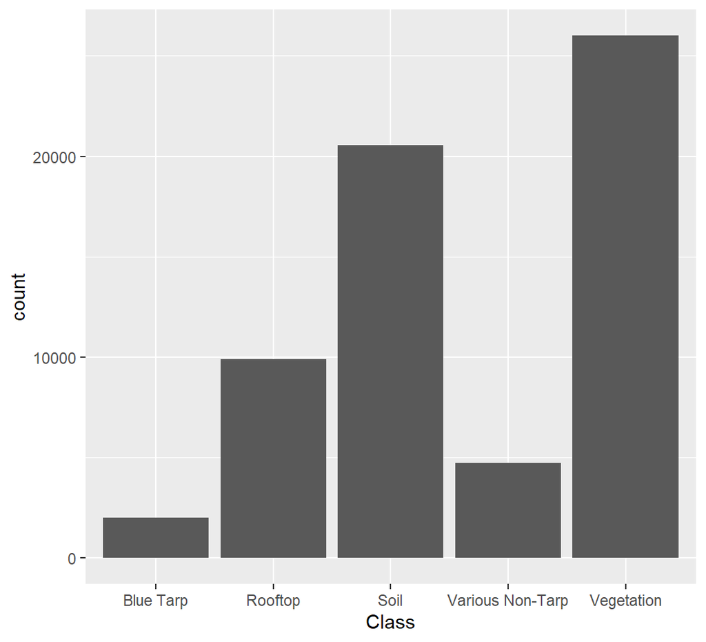

```r
# plot to see count of all the classes
ggplot(data = Training.Data) +
  geom_bar(mapping = aes(x = Class))
```

```r
# Blue Tarp is the least amount of pixels of any of the classes.
Training.Data %>%
  count(Class)
```

```
#>              Class     n
#> 1        Blue Tarp  2022
#> 2          Rooftop  9903
#> 3             Soil 20566
#> 4 Various Non-Tarp  4744
#> 5       Vegetation 26006
```

```r
# Number of classes per each pixel.
by(Training.Data, Training.Data$Class, summary)
```

```
#> Training.Data$Class: Blue Tarp
#>     Class                Red            Green            Blue
#>  Length:2022        Min.   : 93.0   Min.   : 92.0   Min.   : 92.0
#>  Class :character   1st Qu.:147.0   1st Qu.:160.0   1st Qu.:175.2
#>  Mode  :character   Median :168.0   Median :187.0   Median :216.0
#>                     Mean   :169.7   Mean   :186.4   Mean   :205.0
#>                     3rd Qu.:193.0   3rd Qu.:219.0   3rd Qu.:255.0
#>                     Max.   :255.0   Max.   :255.0   Max.   :255.0
#> ------------------------------------------------------------
#> Training.Data$Class: Rooftop
#>     Class                Red            Green            Blue
#>  Length:9903        Min.   : 98.0   Min.   : 87.0   Min.   : 87.0
#>  Class :character   1st Qu.:163.0   1st Qu.:146.0   1st Qu.:123.0
#>  Mode  :character   Median :200.0   Median :191.0   Median :171.0
#>                     Mean   :195.4   Mean   :183.9   Mean   :162.8
#>                     3rd Qu.:222.0   3rd Qu.:215.0   3rd Qu.:192.0
#>                     Max.   :255.0   Max.   :255.0   Max.   :243.0
#> ------------------------------------------------------------
#> Training.Data$Class: Soil
#>     Class                Red            Green            Blue
#>  Length:20566       Min.   :108.0   Min.   : 93.0   Min.   : 83.0
#>  Class :character   1st Qu.:255.0   1st Qu.:215.0   1st Qu.:164.0
#>  Mode  :character   Median :255.0   Median :235.0   Median :178.0
#>                     Mean   :247.9   Mean   :227.5   Mean   :176.7
#>                     3rd Qu.:255.0   3rd Qu.:251.0   3rd Qu.:191.0
#>                     Max.   :255.0   Max.   :255.0   Max.   :255.0
#> ------------------------------------------------------------
#> Training.Data$Class: Various Non-Tarp
#>     Class                Red            Green            Blue
#>  Length:4744        Min.   : 71.0   Min.   : 66.0   Min.   : 60.0
#>  Class :character   1st Qu.:124.0   1st Qu.:110.0   1st Qu.: 88.0
#>  Mode  :character   Median :192.0   Median :160.0   Median :124.0
#>                     Mean   :184.8   Mean   :168.8   Mean   :140.9
#>                     3rd Qu.:255.0   3rd Qu.:247.0   3rd Qu.:191.0
#>                     Max.   :255.0   Max.   :255.0   Max.   :255.0
#> ------------------------------------------------------------
#> Training.Data$Class: Vegetation
#>     Class                Red          Green             Blue
#>  Length:26006       Min.   : 48   Min.   : 48.00   Min.   : 44.00
#>  Class :character   1st Qu.: 68   1st Qu.: 68.00   1st Qu.: 53.00
#>  Mode  :character   Median : 75   Median : 75.00   Median : 58.00
#>                     Mean   : 79   Mean   : 78.45   Mean   : 60.92
#>                     3rd Qu.: 90   3rd Qu.: 87.00   3rd Qu.: 69.00
#>                     Max.   :145   Max.   :153.00   Max.   :101.00
```

```r
# looking at all the summaries of each Class.
```

Looking at the EDA done on this data set I can see now that the least amount of classified pixels in this dataset is blue tarps with vegetation and soil being the most classified pixels. This may present an imbalance when it comes to modeling the data as we want to specifically classify for blue tarps and there are not a lot of examples. Looking at the summary statistics of each class I can see that all the pixels are classified using the same scale so no standardization nor normalization will have to be made upon this data.

# 3 Model Training

## 3.1 Set-up

```r
# Setting up folds for cross-validation.
Training.Data[Training.Data == "Blue Tarp"] <- "1"
Training.Data[Training.Data == "Rooftop"] <- "0"
Training.Data[Training.Data == "Soil"] <- "0"
Training.Data[Training.Data == "Various Non-Tarp"] <- "0"
Training.Data[Training.Data == "Vegetation"] <- "0"
Training.Data$Class <- as.numeric(Training.Data$Class)

CV_perf_table <- data.frame(matrix(ncol = 8, nrow = 9))
colnames(CV_perf_table) <- c("Model", "Tuning", "AUROC", "Threshold", "Accuracy", "TPR", "FPR", "Precision")
CV_perf_table[1, 1] = "Log Reg"
CV_perf_table[2, 1] = "KNN"
CV_perf_table[3, 1] = "Penalized Log Reg"
CV_perf_table[4, 1] = "SVM"
CV_perf_table[5, 1] = "Naive Bayes"
CV_perf_table[6, 1] = "LDA"
CV_perf_table[7, 1] = "QDA"
CV_perf_table[8, 1] = "Random Forests"
CV_perf_table[9, 1] = "Boosted Trees"
```

Since in this project we are only interested in identifying Blue Tarp pixels I have transformed the Class column into a binary indicators with Blue Tarp being “1” and all other classes being “0” since we have no interest in identifying them.

## 3.2 Logistic Regression

```r
set.seed(1)
# Creating a training data and testing data split.
Train <- createDataPartition(Training.Data$Class, p=0.75, list=FALSE)
training.LR <- Training.Data[ Train, ]
testing.LR <- Training.Data[ -Train, ]

# Setting Cross-Validation to 10-folds
ctrl <- trainControl(method = "cv", number = 10, savePredictions = TRUE)

# Training Model with training dats using Logistic Regression.
mod_fitcv <- train(Class~., data=training.LR, method="glm", family="binomial", trControl = ctrl)
```

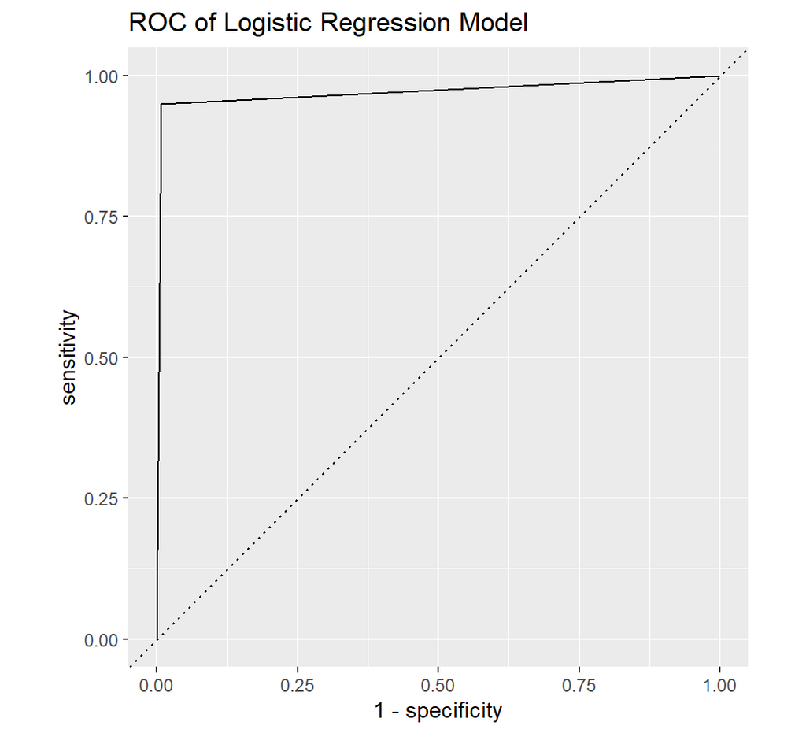

```r
# Using trained model to predict values.
pred.LR <- predict(mod_fitcv, newdata = testing.LR)
# Setting Threshhold for predicted values.
pred.LR <- ifelse(pred.LR > 0.1,1,0)
# Creating Confusion Matrix with predicted and test values.
conf_matrix.LR <- caret::confusionMatrix(table(pred.LR,(testing.LR$Class)))
# Creating ROC Curve built from out of sample data
ROC.LR = tibble(truth = factor(testing.LR$Class, levels =c(1,0)), pred.LR) %>%
  yardstick::roc_curve(truth, pred.LR)

ROC.LR %>%
ggplot(aes(1-specificity, sensitivity)) + geom_line() +
geom_abline(lty=3) +
coord_equal() + ggtitle("ROC of Logistic Regression Model")
```

```r
# Computing AUROC for the Predicted values for Logistic Regression.
AUROC.LR <- yardstick::roc_auc_vec(factor(testing.LR$Class, 1:0), pred.LR)

# Logistic Regression Accuracy.
acc.LR <- conf_matrix.LR$overall
acc.LR <- as.numeric(acc.LR[1])

# Logistic Regression TPR and FPR.
TPR.LR <- ROC.LR[3,3]
FPR.LR <- ROC.LR[3,2]

# Logistic Regression Precision.
precision.LR <- (conf_matrix.LR$table[4]) / (conf_matrix.LR$table[4]+conf_matrix.LR$table[2])

CV_perf_table[1, 2] = "N/A"
CV_perf_table[1, 3] = AUROC.LR
CV_perf_table[1, 4] = "> 0.1"
CV_perf_table[1, 5] = acc.LR
CV_perf_table[1, 6] = TPR.LR
CV_perf_table[1, 7] = FPR.LR
CV_perf_table[1, 8] = precision.LR
```

## 3.3 KNN

```r
set.seed(2)
# Setting up number of folds for Cross-Validation.
n.folds = 10
n = nrow(Training.Data)
fold = sample(rep(1:n.folds, length=n))
K = 1:50
MSE = matrix(NA, length(K), n.folds)
n.val = numeric(n.folds)

# For loop to compute K neighbors for each fold and compute the MSE for each iteration.
for(j in 1:n.folds){

  #-- Set training/val data
  val = which(fold == j)
  train = which(fold != j)
  n.val[j] = length(val)

  #-- fit set of knn models
  for(i in 1:length(K)){
    k = K[i]
    knn = FNN::knn.reg(train = Training.Data[train,, drop=FALSE],
                       y = Training.Data$Class[train],
                       test = Training.Data[val,, drop=FALSE],
                       k = k)
    r.val = Training.Data$Class[val]-knn$pred      # residuals on val data
    MSE[i, j] = mean(r.val^2)
  }
}

# Calculating MSE to find which K neighbor gives us the least amount of MSE.
CV = (MSE %*% n.val)/n
SE = apply(MSE, 1, sd)/sqrt(n.folds)
results.knn = tibble(k = K, MSE = CV[,1], SE)
results.knn
```

```
#> # A tibble: 50 x 3
#>        k     MSE       SE
#>    <int>   <dbl>    <dbl>
#>  1     1 0.00251 0.000271
#>  2     2 0.00193 0.000192
#>  3     3 0.00182 0.000162
#>  4     4 0.00181 0.000166
#>  5     5 0.00173 0.000157
#>  6     6 0.00172 0.000153
#>  7     7 0.00172 0.000155
#>  8     8 0.00171 0.000152
#>  9     9 0.00169 0.000155
#> 10    10 0.00165 0.000146
#> # ... with 40 more rows
```

```r
opt.K <- results.knn %>%
  filter(min_rank(MSE) == 1)
opt.K
```

```
#> # A tibble: 1 x 3
#>       k     MSE       SE
#>   <int>   <dbl>    <dbl>
#> 1    10 0.00165 0.000146
```

```r
# 10 CV training Running model with optimal K neighbor.
K = 10 # folds
folds = rep(1:K, length=nrow(Training.Data)) %>% sample()
for(k in 1:K){
test = (folds == k)
train = (folds != k)
knn = FNN::knn.reg(train = Training.Data[train,],
                       y = Training.Data$Class[train],
                       test = Training.Data[test,],
                       k = opt.K$k)
}

# Setting Threshold to 0.1
pred.knn <- ifelse(knn$pred > 0.1,1,0)

# Creating Confusion Matrix
cm.knn <- table(Training.Data$Class[val],pred.knn)
cm.knn
```

```
#>    pred.knn
#>        0    1
#>   0 6109   15
#>   1    1  199
```

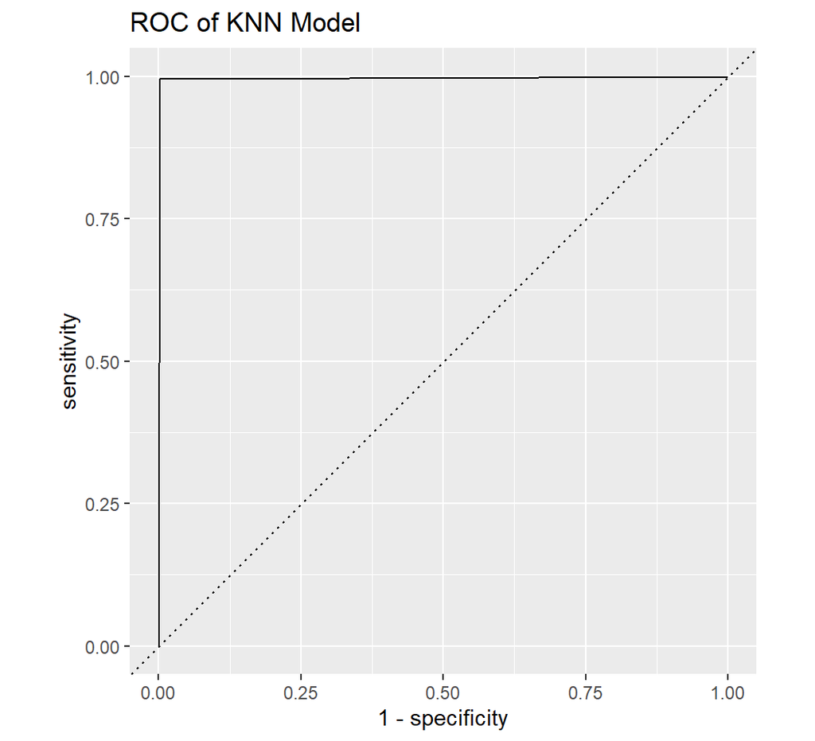

```r
# KNN Accuracy.
acc.knn <-calc_acc(actual = Training.Data$Class[val],
         pred.knn)

# Creating ROC Curve built from out of sample data
ROC.knn = tibble(truth = factor(Training.Data$Class[val], levels =c(1,0)), pred.knn) %>%
  yardstick::roc_curve(truth, pred.knn)

ROC.knn %>%
ggplot(aes(1-specificity, sensitivity)) + geom_line() +
geom_abline(lty=3) +
coord_equal() + ggtitle("ROC of KNN Model")
```

```r
Test.knn <- Training.Data[val,, drop=FALSE]

# Computing AUROC for the Predicted values for KNN.
AUROC.knn <- yardstick::roc_auc_vec(factor(Test.knn$Class, 1:0),  pred.knn)


# KNN Precision.
precision.knn <- (cm.knn[2,2]) / (cm.knn[2,1]+cm.knn[2,2])

# KNN TPR and FPR.
TPR.knn <- ROC.knn[3,3]
FPR.knn <- ROC.knn[3,2]

CV_perf_table[2, 2] = opt.K$k
CV_perf_table[2, 3] = AUROC.knn
CV_perf_table[2, 4] = "> 0.1"
CV_perf_table[2, 5] = acc.knn
CV_perf_table[2, 6] = TPR.knn
CV_perf_table[2, 7] = FPR.knn
CV_perf_table[2, 8] = precision.knn
```

### 3.3.1 Tuning Parameter $k$

Tuning parameter $k$ neighbor for the KNN model was determined by running a for loop with 10-fold cross validation through a training model that cycled through different $k$ values from 1 through 50 and testing the model on the validation set to calculate the MSE for the given $k$ value. From the 50 $k$ values that were tested the model with the lowest MSE was chosen as the most optimal $k$ parameter.

## 3.4 Penalized Logistic Regression (ElasticNet)

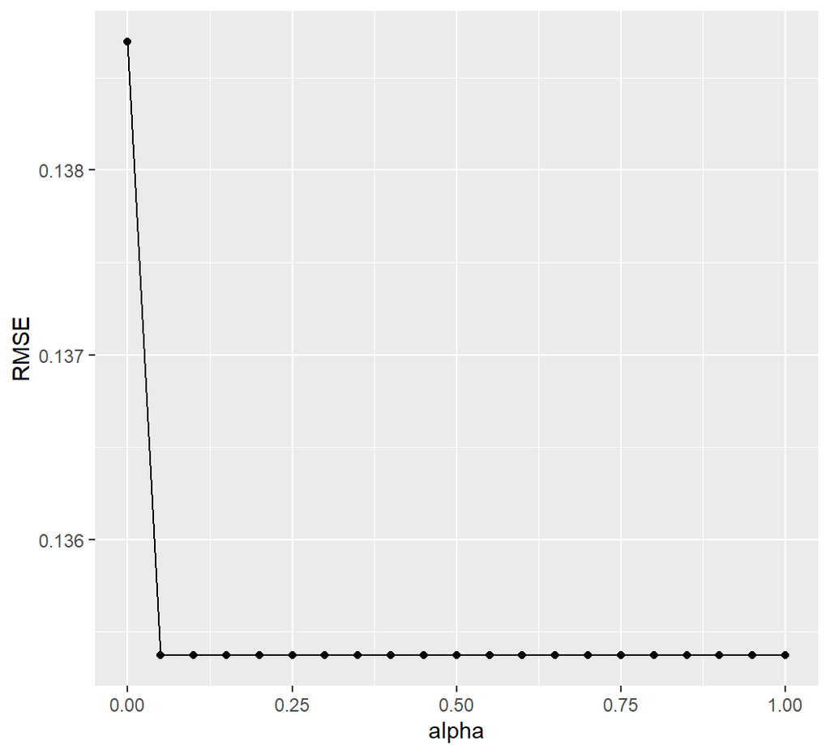

```r
set.seed(3)
# Elastic Net
# Creating Testing and Training Data for Elastic Net.
Training.Data.EN <- Training.Data
n = nrow(Training.Data.EN)
n_hout = 500
hout = sample(n, size = n_hout)
hout_data = Training.Data.EN[hout,]
Training.Data.EN = Training.Data.EN[-hout,]
x.train = glmnet::makeX(Training.Data.EN[,2:4])
Y.train = Training.Data.EN$Class
hout_data_x = glmnet::makeX(hout_data[,2:4])
hout_data_y = hout_data$Class
alpha.seq = seq(0, 1, by=.05)

K = 10           # number of folds
folds = rep(1:K, length=nrow(x.train)) %>% sample() # make folds

est_rmse <- function(alpha, folds){
  min(cv.glmnet(x.train, Y.train, foldid = folds, alpha=alpha)$cvm) %>% sqrt()
}

RMSE2 = tibble()
for(i in 1:10){
  folds_new = sample(folds) # shuffle folds
  rmse = tibble(iter = i, alpha=alpha.seq,
                RMSE = sapply(alpha.seq, est_rmse, folds=folds_new))
  RMSE2 = bind_rows(RMSE2, rmse)
}

RMSE.mu = RMSE2 %>%
  group_by(alpha) %>% summarize(RMSE=mean(RMSE), RMSE.median = median(RMSE))

RMSE.mu %>%
  group_by(alpha) %>% summarize(RMSE=mean(RMSE)) %>%
  ggplot(aes(alpha, RMSE)) + geom_point() + geom_line()
```

```r
RMSE.mu %>% arrange(RMSE)
```

```
#> # A tibble: 21 x 3
#>    alpha  RMSE RMSE.median
#>    <dbl> <dbl>       <dbl>
#>  1  0.65 0.135       0.135
#>  2  0.4  0.135       0.135
#>  3  0.6  0.135       0.135
#>  4  0.15 0.135       0.135
#>  5  0.5  0.135       0.135
#>  6  0.3  0.135       0.135
#>  7  0.25 0.135       0.135
#>  8  0.85 0.135       0.135
#>  9  0.35 0.135       0.135
#> 10  0.45 0.135       0.135
#> # ... with 11 more rows
```

```r
(alpha.hat = RMSE.mu %>% slice_min(RMSE) %>% pull(alpha) )
```

```
#> [1] 0.65
```

```r
alpha.hat # optimal alpha after tuning.
```

```
#> [1] 0.65
```

```r
# Setting up logistic regression model and training with training data.
a = alpha.hat  # setting alpha for elastic net
fit.enet = cv.glmnet(x = x.train, y=as.factor(Y.train), alpha=a, nfolds = 10, family="binomial")

(lambda.hat = fit.enet$lambda.min)
```

```
#> [1] 6.416034e-06
```

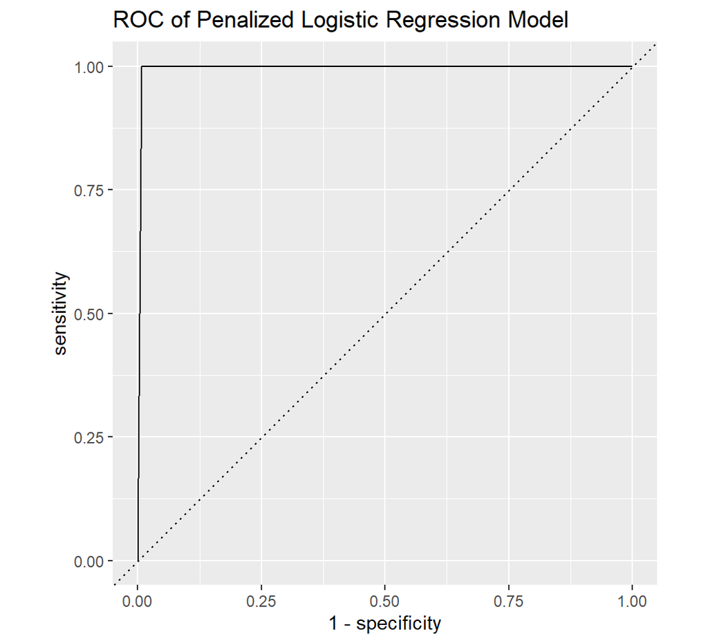

```r
# Making predictions with model.
pred.EN = predict(fit.enet, s=lambda.hat, newx=hout_data_x, type="response")[,1]
# Threshold for predictions.
pred.EN <- ifelse(pred.EN > 0.1,1,0)

# Elasticnet Confusion Matrix
conf_matrix.EN <- confusionMatrix(as.factor(pred.EN),as.factor(hout_data_y))

# Elasticnet Accuracy
acc.EN <- calc_acc(actual = hout_data_y,
         pred.EN)

# Elasticnet ROC Curve built from out of sample data
ROC.EN = tibble(truth = factor(hout_data_y, levels =c(1,0)), pred.EN) %>%
  yardstick::roc_curve(truth, pred.EN)

ROC.EN %>%
ggplot(aes(1-specificity, sensitivity)) + geom_line() +
geom_abline(lty=3) +
coord_equal() + ggtitle("ROC of Penalized Logistic Regression Model")
```

```r
# Elasticnet AUROC
AUROC.EN <- yardstick::roc_auc_vec(factor(hout_data_y, 1:0), pred.EN)
cm.EN <- table(hout_data_y,pred.EN)
cm.EN
```

```
#>            pred.EN
#> hout_data_y   0   1
#>           0 485   4
#>           1   0  11
```

```r
# Elacticnet Precision
precision.EN <- (cm.EN[2,2]) / (cm.EN[2,1]+cm.EN[2,2])

# Elasticnet TPR and FPR
TPR.EN <- ROC.EN[3,3]
FPR.EN <- ROC.EN[3,2]

CV_perf_table[3, 2] = "alpha = 0.65 and lambda = 6.416034e-06"
CV_perf_table[3, 3] = AUROC.EN
CV_perf_table[3, 4] = "> 0.1"
CV_perf_table[3, 5] = acc.EN
CV_perf_table[3, 6] = TPR.EN
CV_perf_table[3, 7] = FPR.EN
CV_perf_table[3, 8] = precision.EN
```

### 3.4.1 Tuning Parameters $\lambda$ and $\alpha$

The parameters that needed to be tuned for the Penalized Logistic Regression model are $\lambda$ and $\alpha$. The way I chose the optimal $\alpha$ was by runing a for loop for various iterations to test out alpha values incrementing at 0.05 steps and then calculating the RMSE of each alpha to find out which one gave the lowest RMSE value and is therefore my optimal $\alpha$. Once finding the optimal $\alpha$ it was then plugged into the cv.glmnet() function and the optimal $\lambda$ was then returned.